# TidyR Module: Final Project

Kalina Larsen

2023-11-06

Goal: Observe the difference in protein expressing between the distal and proximal ends of the sciatic nerve in human specimens.

To obtain this data 37 sciatic nerve tissue samples which were kept at -80C until sent to be processed at the Duke Proteomics and Metabolomics Core Facility (DPMCF).

First, I wanted to visualize the concentration of proteins in the sample (ug/uL)

[figure not shown]

```r
NonResolved <- PatientPain %>%
  filter(Month == "6 Months") %>%
  filter(Pain_NRS > 2) %>%
  mutate(Type = "NonResolved")

Resolved <- PatientPain %>%
  filter(Month == "6 Months") %>%
  filter(Pain_NRS < 3) %>%
  mutate(Type = "Resolved")

# Combine the patient groups into single table
Sorted_Patient_Data <- bind_rows(NonResolved, Resolved)
```

Using the patient pain outcome information, I visualized if protein exprression was any different between the two patient populations and location in sciatic nerve.

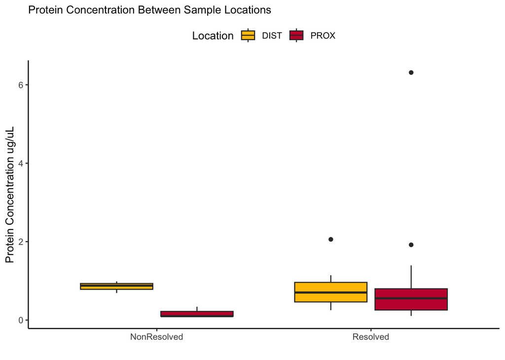

```r
custome_colors <- c("#FFC300", "#C70039")


CombinedProxDist %>%
  ggplot(aes(x = Type, y = `Protein Concentration`))+
  geom_boxplot(aes(fill = Location)) +
  scale_fill_manual(values = custome_colors) +
  # geom_jitter(color="black", size=1) +
  theme_classic() +
    theme(
      legend.position="none",
      plot.title = element_text(size=11)) +
    ggtitle("Protein Concentration Between Sample Locations") +
    xlab("") +
    ylab("Protein Concentration ug/uL")+
    theme(legend.position = "top")
```

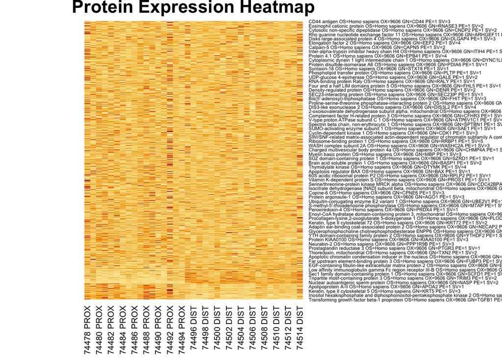

```r
SelectedProeomics <- Proteomics_Data %>%
  select(Description, `74478 PROX`: `74514 DIST`)

# First, get the data in the correct matrix format (numeric)
SelectedProeomics[, 2:38] <- sapply(SelectedProeomics[, 2:38], as.numeric)

# Now, create a heatmap
heatmap_data1 <- as.matrix(SelectedProeomics[, 2:38])
rownames(heatmap_data1) <- SelectedProeomics$Description

# Customize the heatmap
heatmap(heatmap_data1, scale = "row", Colv = NA, Rowv = NA, margins = c(5, 10), main = "Protein Expression Heatmap")
```

This heatmap is a lot to look at. It includes the 37 samples across x-axis and the unique proteins across the y-axis. There are 3,774 unique proteins and this visualization makes it really hard to see anything.

So, I decided to look at which proteins were being expressed differently between the proximal and distal samples. I plotted the fold change in protein amount detected across the 3,774 proteins.

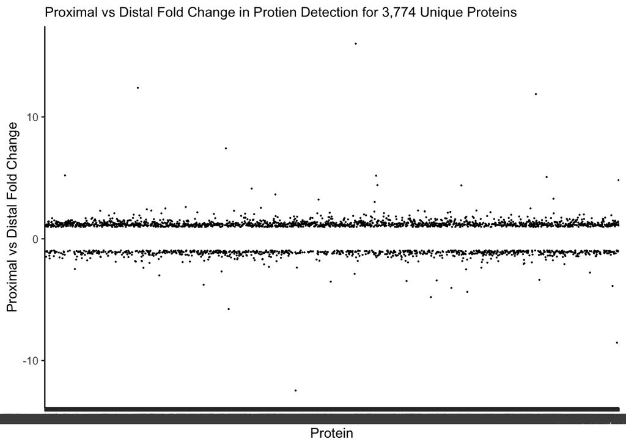

```r
FoldChangeProeomics <- Proteomics_Data %>%
  select(Accession, Description, `PROX_v_DIST_FC`, `PROX_v_DIST_MF`) %>%
  filter(PROX_v_DIST_MF == 1)

FoldChangeProeomics %>%
  ggplot(aes(x = Description, y = `PROX_v_DIST_FC`)) +
  geom_jitter(color="black", size=0.1) +
   theme_classic() +
    theme(
      legend.position="none",
      plot.title = element_text(size=11)
    ) +
    ggtitle("Proximal vs Distal Fold Change in Protien Detection for 3,774 Unique Proteins") +
    xlab("Protein") +
    ylab("Proximal vs Distal Fold Change")
```

I can see from this chart that there are several proteins which are more strongly expressed in one location than the other, thus I want to identify which these are. I also decided to plot them.

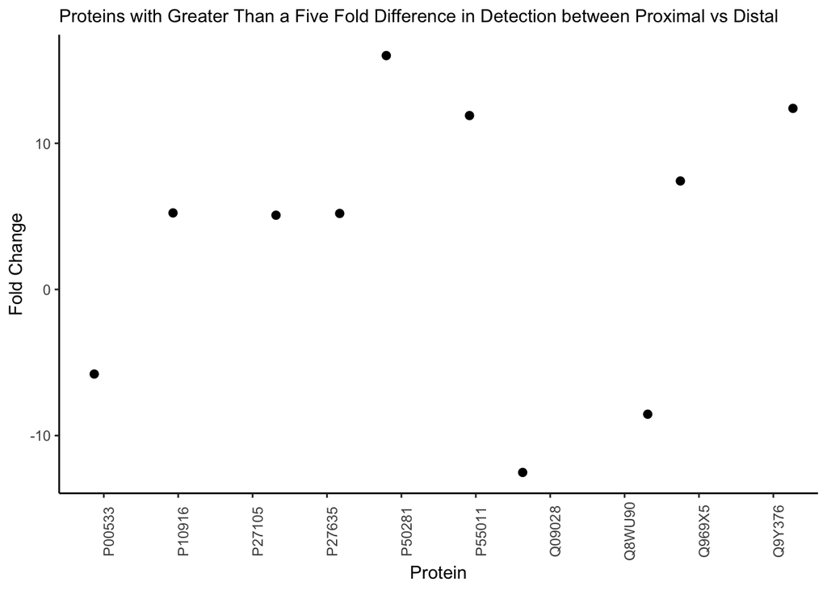

Proteins with Greater Than a Five Fold Difference in Detection between Proximal vs Distal

| Accession | Description | PROX_v_DIST_FC | PROX_v_DIST_MF |
| --- | --- | --- | --- |
| P50281 | Matrix metalloproteinase-14 | 16.0 | 1 |
| P55011 | Solute carrier family 12 member 2 | 11.9 | 1 |
| Q969X5 | Endoplasmic reticulum-Golgi intermediate compartment protein 1 | 7.4 | 1 |
| Q9Y376 | Calcium-binding protein 39 | 12.4 | 1 |
| P10916 | Myosin regulatory light chain 2, ventricular/cardiac muscle isoform | 5.2 | 1 |
| Q09028 | Histone-binding protein RBBP4 | -12.5 | 1 |
| Q8WU90 | Zinc finger CCCH domain-containing protein 15 | -8.5 | 1 |
| P00533 | Epidermal growth factor receptor | -5.8 | 1 |
| P27105 | Stomatin | 5.1 | 1 |
| P27635 | 60S ribosomal protein L10 | 5.2 | 1 |

```r
# Plot only the proteins where there is greater than a five fold difference between proximal and distal
subset_data <- subset(FoldChangeProeomics, PROX_v_DIST_FC > 5 | PROX_v_DIST_FC < -5)

# Clean up Protein description
subset_data$Description <- sub( "OS.*", "", subset_data$Description)

# Plot the proteins who have greater than a five fold difference between proximal and distal
subset_data %>%
  ggplot(aes(x = Accession, y = `PROX_v_DIST_FC`)) +
  geom_jitter(color="black", size=2) +
   theme_classic() +
    theme(
      legend.position="none",
      plot.title = element_text(size=11)
    ) +
    ggtitle("Proteins with Greater Than a Five Fold Difference in Detection between Proximal vs Distal") +
    xlab("Protein") +
    ylab("Fold Change")+
    theme(axis.text.x = element_text(angle = 90))
```

Now that I have identified 10 proteins which are observed to have the more different expression, I can make another heat map to observe their concentration between the samples.

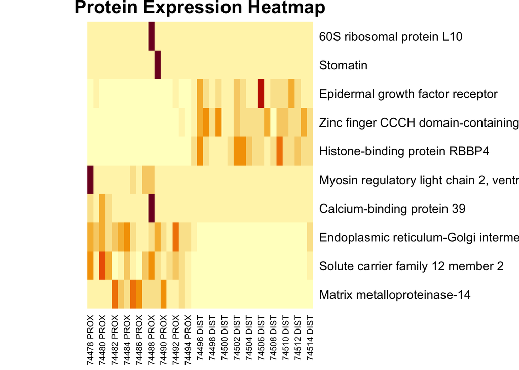

```r
# First, make sure the data is in the correct format (numeric)
SignificantProteins[, 2:38] <- sapply(SignificantProteins[, 2:38], as.numeric)

# Now, create a heatmap
heatmap_data <- as.matrix(SignificantProteins[, 2:38])  # Assuming columns 2 to 38 are the concentrations
rownames(heatmap_data) <- SignificantProteins$Description  # Assuming the first column is 'Description'

# Customize the heatmap as needed
heatmap(heatmap_data, scale = "row", Colv = NA, Rowv = NA, margins = c(5, 10), main = "Protein Expression Heatmap")
```

## Conclusion

Initial analysis was able to identify proteins that are expressed at differently between proximal and distal locations of the sciatic nerve. Much more analysis of this proteomics data is necessary.